# Data organization and wrangling

Abel Torres Espin

March 2023

# Data organization

A good data organization is important for an efficient management, analysis, provenance, sharing and reproducibility. Well-organized data will save a lot of work and can prevent common research issues.

Data organization is part of the field of data management and knowledge/record archiving, and spans several disciplines, from computer science to library science. Here we will talk about the specific of organizing data observations into tabular formats (rows and columns) such as spreadsheets. Tabular formats are simple in its conception, but when used properly, they can be powerful tools for data organization.

## Organizing data: archiving vs. analysis, human vs. machine

A common practice in biomedical research is to enter the data into a software in a format that allows for analysis and/or for human understanding. For example, we have all entered data into a spreadsheet as in the image below.

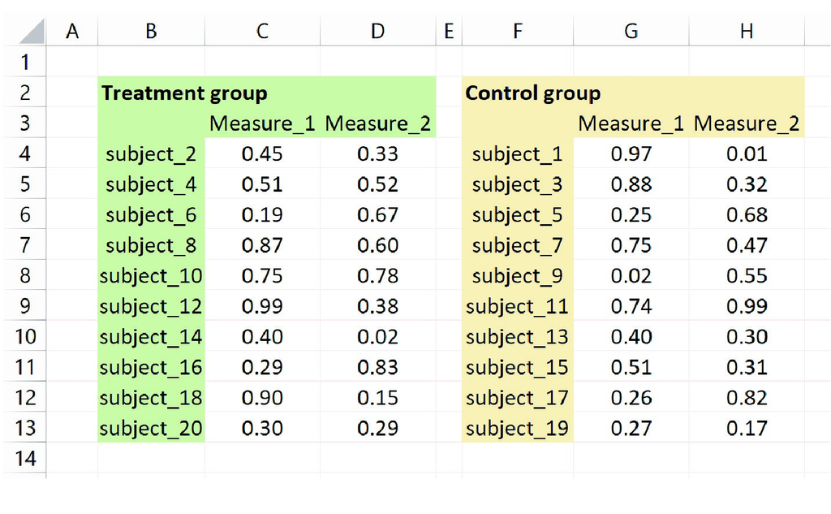

This is great for us to do some quick analysis, for instance, we can quickly calculate the average of each column, or the standard deviation. It is also very easy for us humans to understand what is going on in this datasets. However, this way of organizing data brings several limitations:

- If we want to do something else that the data is not well-formatted for, we will need to rework the dataset for every thing we want to do (e.g., a different analysis, different plots).
- The organization is not understandable by machines. We know what “subject_2” means or we can probably guess right even if we have not created this dataset. But a computer will not understand it (unless we tall them). Also, this organization doesn’t seem to follow a standardized format, which means that there is a big chance that next time we enter the data slightly different.
- The more difficult we make reading datasets by machines, the more we will have to do repetitive manual work. We can use the power of computers to automatize or easy some tasks if we follow a few simple rules.

Now you should be able to see how conceptually, organizing data to be understood only by you, and directed to a specific analysis, is making your life as a researcher more difficult than it needs to be.

A well-structured dataset to organize and manage all your data can give the flexibility to quickly format data for specific analysis, and make it readable by machines, such that we can take advantage of computers, like this one:

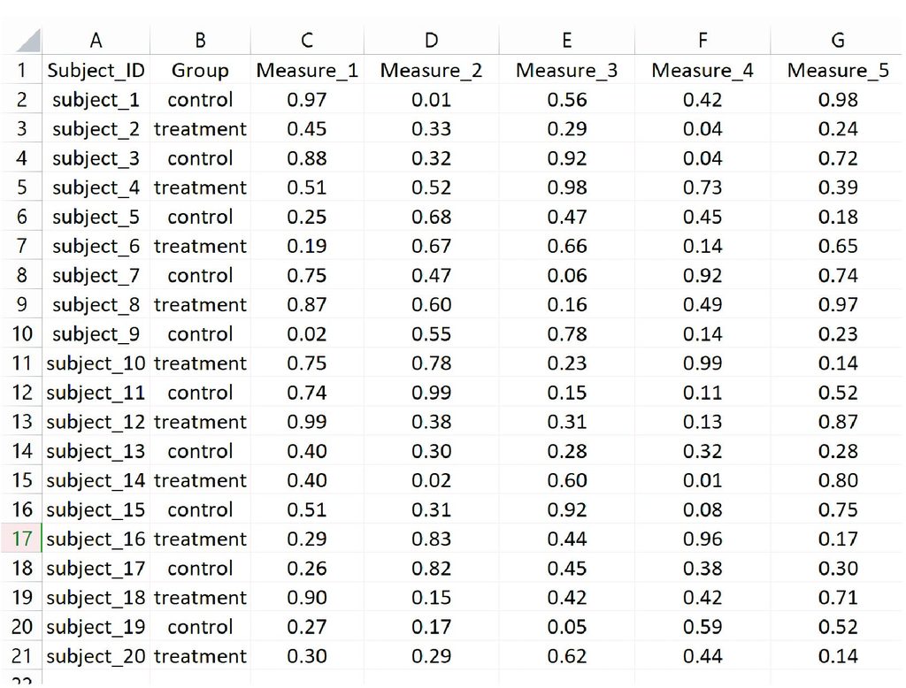

machine readable image

## Organizing data in spreadsheets

Most of the content of this section comes from this great paper on the organization of data in spreadsheets:

> Karl W. Broman & Kara H. Woo (2018) Data Organization in Spreadsheets, The American Statistician, 72:1, 2-10, DOI: 10.1080/00031305.2017.1375989

### The Tidy format

The basics are simple: each row is an observation, and each column is a measure, field, or variable. The first row contains the column names, also refered as headers or variable names. The previous image is a dataset organized in the tidy format. A tidy data format is a great way to make data understandable by humans and machines!

[figure not shown]

tidy format image

### Some recomendations

# Data wrangling in R

Data wrangling refers to the process of reformatting and processing a dataset to a target format for some specific goal. Even though having data in a tidy format helps to reduce a lot of the challenges of working with tabular data, it is often the case we may want to do different transformations to joint different datasets, summarize data, prepare data for analysis and visualization, crease specific subsets of data, or prepare data for other data processing pipelines.

This section will show some of the common data wrangling procedures using R and the tidyverse set of tools.

> Note. I find data wrangling one of the most important skills that one can learn around data. As a data practitioner (such as wet lab biomedical researchers), you will spend a lot of time cleaning and re-working datasets, and this set of technics will help to do it fast, efficiently, and reduce errors.

## The Tidyverse

Tidyverse is probably the most used universe of R packages. A package is an R extension (also called library) that adds specific functions to R. A universe contains several packages with integrated and interoperable functionalities. The tidyverse combines packages and functions mostly related to data wrangling, operations and graphics

**Installing a package**

```r
# From CRAN
# install.packages("tidyverse")
```

**Loading a package to current R session**

```r
library(tidyverse)
```

### dplyr and “piping”

A handy [cheatsheet](https://www.rstudio.com/wp-content/uploads/2015/02/data-wrangling-cheatsheet.pdf)

Tidyverse contains the dplyr package, a framework for data wrangling. It contains a set of functions that we call verbs and allow us to operate and transform a dataframe object.

“Piping” using the pipe operator (*%>%* for the magrittr package, or *|>* from base R) allow to chain different processes without having to break our code.

```
# Common dplyr syntax with piping

df %>%
  do_this_to_df %>%
  then_do_this_other_thing %>%
  then_do_this_other_thing ...
```

#### Filter, select and mutate

**Filter and select**

```r
my_data<-mtcars
head(my_data)
```

```
##                    mpg cyl disp  hp drat    wt  qsec vs am gear carb
## Mazda RX4         21.0   6  160 110 3.90 2.620 16.46  0  1    4    4
## Mazda RX4 Wag     21.0   6  160 110 3.90 2.875 17.02  0  1    4    4
## Datsun 710        22.8   4  108  93 3.85 2.320 18.61  1  1    4    1
## Hornet 4 Drive    21.4   6  258 110 3.08 3.215 19.44  1  0    3    1
## Hornet Sportabout 18.7   8  360 175 3.15 3.440 17.02  0  0    3    2
## Valiant           18.1   6  225 105 2.76 3.460 20.22  1  0    3    1
```

```r
my_data%>%
  filter(disp < 100)
```

```
##                 mpg cyl disp  hp drat    wt  qsec vs am gear carb
## Fiat 128       32.4   4 78.7  66 4.08 2.200 19.47  1  1    4    1
## Honda Civic    30.4   4 75.7  52 4.93 1.615 18.52  1  1    4    2
## Toyota Corolla 33.9   4 71.1  65 4.22 1.835 19.90  1  1    4    1
## Fiat X1-9      27.3   4 79.0  66 4.08 1.935 18.90  1  1    4    1
## Lotus Europa   30.4   4 95.1 113 3.77 1.513 16.90  1  1    5    2
```

```r
my_data%>%
  filter(disp < 100, gear == 5)
```

```
##               mpg cyl disp  hp drat    wt qsec vs am gear carb
## Lotus Europa 30.4   4 95.1 113 3.77 1.513 16.9  1  1    5    2
```

```r
my_data%>%
  select(mpg, disp, wt)
```

```
##                      mpg  disp    wt
## Mazda RX4           21.0 160.0 2.620
## Mazda RX4 Wag       21.0 160.0 2.875
## Datsun 710          22.8 108.0 2.320
## Hornet 4 Drive      21.4 258.0 3.215
## Hornet Sportabout   18.7 360.0 3.440
## Valiant             18.1 225.0 3.460
## Duster 360          14.3 360.0 3.570
## Merc 240D           24.4 146.7 3.190
## Merc 230            22.8 140.8 3.150
## Merc 280            19.2 167.6 3.440
## Merc 280C           17.8 167.6 3.440
## Merc 450SE          16.4 275.8 4.070
## Merc 450SL          17.3 275.8 3.730
## Merc 450SLC         15.2 275.8 3.780
## Cadillac Fleetwood  10.4 472.0 5.250
## Lincoln Continental 10.4 460.0 5.424
## Chrysler Imperial   14.7 440.0 5.345
## Fiat 128            32.4  78.7 2.200
## Honda Civic         30.4  75.7 1.615
## Toyota Corolla      33.9  71.1 1.835
## Toyota Corona       21.5 120.1 2.465
## Dodge Challenger    15.5 318.0 3.520
## AMC Javelin         15.2 304.0 3.435
## Camaro Z28          13.3 350.0 3.840
## Pontiac Firebird    19.2 400.0 3.845
## Fiat X1-9           27.3  79.0 1.935
## Porsche 914-2       26.0 120.3 2.140
## Lotus Europa        30.4  95.1 1.513
## Ford Pantera L      15.8 351.0 3.170
## Ferrari Dino        19.7 145.0 2.770
## Maserati Bora       15.0 301.0 3.570
## Volvo 142E          21.4 121.0 2.780
```

```r
my_data%>%
  filter(disp < 100)%>%
  select(mpg, disp, wt)
```

```
##                 mpg disp    wt
## Fiat 128       32.4 78.7 2.200
## Honda Civic    30.4 75.7 1.615
## Toyota Corolla 33.9 71.1 1.835
## Fiat X1-9      27.3 79.0 1.935
## Lotus Europa   30.4 95.1 1.513
```

**Mutate**

```r
my_data%>%
  mutate(size = ifelse(wt > 2, "big", "small"))
```

```
##                      mpg cyl  disp  hp drat    wt  qsec vs am gear carb  size
## Mazda RX4           21.0   6 160.0 110 3.90 2.620 16.46  0  1    4    4   big
## Mazda RX4 Wag       21.0   6 160.0 110 3.90 2.875 17.02  0  1    4    4   big
## Datsun 710          22.8   4 108.0  93 3.85 2.320 18.61  1  1    4    1   big
## Hornet 4 Drive      21.4   6 258.0 110 3.08 3.215 19.44  1  0    3    1   big
## Hornet Sportabout   18.7   8 360.0 175 3.15 3.440 17.02  0  0    3    2   big
## Valiant             18.1   6 225.0 105 2.76 3.460 20.22  1  0    3    1   big
## Duster 360          14.3   8 360.0 245 3.21 3.570 15.84  0  0    3    4   big
## Merc 240D           24.4   4 146.7  62 3.69 3.190 20.00  1  0    4    2   big
## Merc 230            22.8   4 140.8  95 3.92 3.150 22.90  1  0    4    2   big
## Merc 280            19.2   6 167.6 123 3.92 3.440 18.30  1  0    4    4   big
## Merc 280C           17.8   6 167.6 123 3.92 3.440 18.90  1  0    4    4   big
## Merc 450SE          16.4   8 275.8 180 3.07 4.070 17.40  0  0    3    3   big
## Merc 450SL          17.3   8 275.8 180 3.07 3.730 17.60  0  0    3    3   big
## Merc 450SLC         15.2   8 275.8 180 3.07 3.780 18.00  0  0    3    3   big
## Cadillac Fleetwood  10.4   8 472.0 205 2.93 5.250 17.98  0  0    3    4   big
## Lincoln Continental 10.4   8 460.0 215 3.00 5.424 17.82  0  0    3    4   big
## Chrysler Imperial   14.7   8 440.0 230 3.23 5.345 17.42  0  0    3    4   big
## Fiat 128            32.4   4  78.7  66 4.08 2.200 19.47  1  1    4    1   big
## Honda Civic         30.4   4  75.7  52 4.93 1.615 18.52  1  1    4    2 small
## Toyota Corolla      33.9   4  71.1  65 4.22 1.835 19.90  1  1    4    1 small
## Toyota Corona       21.5   4 120.1  97 3.70 2.465 20.01  1  0    3    1   big
## Dodge Challenger    15.5   8 318.0 150 2.76 3.520 16.87  0  0    3    2   big
## AMC Javelin         15.2   8 304.0 150 3.15 3.435 17.30  0  0    3    2   big
## Camaro Z28          13.3   8 350.0 245 3.73 3.840 15.41  0  0    3    4   big
## Pontiac Firebird    19.2   8 400.0 175 3.08 3.845 17.05  0  0    3    2   big
## Fiat X1-9           27.3   4  79.0  66 4.08 1.935 18.90  1  1    4    1 small
## Porsche 914-2       26.0   4 120.3  91 4.43 2.140 16.70  0  1    5    2   big
## Lotus Europa        30.4   4  95.1 113 3.77 1.513 16.90  1  1    5    2 small
## Ford Pantera L      15.8   8 351.0 264 4.22 3.170 14.50  0  1    5    4   big
## Ferrari Dino        19.7   6 145.0 175 3.62 2.770 15.50  0  1    5    6   big
## Maserati Bora       15.0   8 301.0 335 3.54 3.570 14.60  0  1    5    8   big
## Volvo 142E          21.4   4 121.0 109 4.11 2.780 18.60  1  1    4    2   big
```

```r
my_data%>%
  mutate(size = ifelse(wt > 2, "big", "small"),
         cyl_gear = paste(cyl, gear, sep = "_"))
```

```
##                      mpg cyl  disp  hp drat    wt  qsec vs am gear carb  size
## Mazda RX4           21.0   6 160.0 110 3.90 2.620 16.46  0  1    4    4   big
## Mazda RX4 Wag       21.0   6 160.0 110 3.90 2.875 17.02  0  1    4    4   big
## Datsun 710          22.8   4 108.0  93 3.85 2.320 18.61  1  1    4    1   big
## Hornet 4 Drive      21.4   6 258.0 110 3.08 3.215 19.44  1  0    3    1   big
## Hornet Sportabout   18.7   8 360.0 175 3.15 3.440 17.02  0  0    3    2   big
## Valiant             18.1   6 225.0 105 2.76 3.460 20.22  1  0    3    1   big
## Duster 360          14.3   8 360.0 245 3.21 3.570 15.84  0  0    3    4   big
## Merc 240D           24.4   4 146.7  62 3.69 3.190 20.00  1  0    4    2   big
## Merc 230            22.8   4 140.8  95 3.92 3.150 22.90  1  0    4    2   big
## Merc 280            19.2   6 167.6 123 3.92 3.440 18.30  1  0    4    4   big
## Merc 280C           17.8   6 167.6 123 3.92 3.440 18.90  1  0    4    4   big
## Merc 450SE          16.4   8 275.8 180 3.07 4.070 17.40  0  0    3    3   big
## Merc 450SL          17.3   8 275.8 180 3.07 3.730 17.60  0  0    3    3   big
## Merc 450SLC         15.2   8 275.8 180 3.07 3.780 18.00  0  0    3    3   big
## Cadillac Fleetwood  10.4   8 472.0 205 2.93 5.250 17.98  0  0    3    4   big
## Lincoln Continental 10.4   8 460.0 215 3.00 5.424 17.82  0  0    3    4   big
## Chrysler Imperial   14.7   8 440.0 230 3.23 5.345 17.42  0  0    3    4   big
## Fiat 128            32.4   4  78.7  66 4.08 2.200 19.47  1  1    4    1   big
## Honda Civic         30.4   4  75.7  52 4.93 1.615 18.52  1  1    4    2 small
## Toyota Corolla      33.9   4  71.1  65 4.22 1.835 19.90  1  1    4    1 small
## Toyota Corona       21.5   4 120.1  97 3.70 2.465 20.01  1  0    3    1   big
## Dodge Challenger    15.5   8 318.0 150 2.76 3.520 16.87  0  0    3    2   big
## AMC Javelin         15.2   8 304.0 150 3.15 3.435 17.30  0  0    3    2   big
## Camaro Z28          13.3   8 350.0 245 3.73 3.840 15.41  0  0    3    4   big
## Pontiac Firebird    19.2   8 400.0 175 3.08 3.845 17.05  0  0    3    2   big
## Fiat X1-9           27.3   4  79.0  66 4.08 1.935 18.90  1  1    4    1 small
## Porsche 914-2       26.0   4 120.3  91 4.43 2.140 16.70  0  1    5    2   big
## Lotus Europa        30.4   4  95.1 113 3.77 1.513 16.90  1  1    5    2 small
## Ford Pantera L      15.8   8 351.0 264 4.22 3.170 14.50  0  1    5    4   big
## Ferrari Dino        19.7   6 145.0 175 3.62 2.770 15.50  0  1    5    6   big
## Maserati Bora       15.0   8 301.0 335 3.54 3.570 14.60  0  1    5    8   big
## Volvo 142E          21.4   4 121.0 109 4.11 2.780 18.60  1  1    4    2   big
##                     cyl_gear
## Mazda RX4                6_4
## Mazda RX4 Wag            6_4
## Datsun 710               4_4
## Hornet 4 Drive           6_3
## Hornet Sportabout        8_3
## Valiant                  6_3
```

[output cut: 11 more lines]

```
## Fiat 128                 4_4
## Honda Civic              4_4
## Toyota Corolla           4_4
## Toyota Corona            4_3
## Dodge Challenger         8_3
## AMC Javelin              8_3
## Camaro Z28               8_3
## Pontiac Firebird         8_3
## Fiat X1-9                4_4
## Porsche 914-2            4_5
## Lotus Europa             4_5
## Ford Pantera L           8_5
## Ferrari Dino             6_5
## Maserati Bora            8_5
## Volvo 142E               4_4
```

### Other important dplyr functions

There is a lot to explore in dplyr and the rest of the tidyverse. We will talk about graphics in the data viz class. Other verbs that you probably will need are: *group_by* and *summarize*. Check them out!